# Statistical inference with the GSS data

## POST 2008

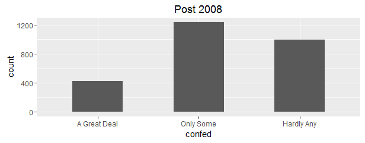

Post2008

```r
post2008 <-gss %>% filter(!(is.na(confed)) & year>= "2009" & year <= "2012")
ggplot(data=post2008, aes(x=confed)) + geom_bar(width=.5) + labs(title = "Post 2008")}
```

NARRATIVE:

The above plot shows the distribution of the categorical variable CONFED between its levels from 2009 to 2012 (POST 2008) observed by a random sample.

```r
post2008 %>% mutate(great=ifelse(confed=="A Great Deal",1,0)) %>% summarise(Great=sum(great==1), N=n(), Great_Post2008_Percent=sum(great==1)/n())}
```

```r
Great <- c(423)
N <- c(2653)
Great_Post2008_Percent <- c(0.1594)
grdff <- data.frame(Great, N, Great_Post2008_Percent)
grdff}
```

```r
    Great    N        Great_Post2008_Percent
1   423     2653      0.1594}
```

```r
post2008  %>% mutate(some=ifelse(confed=="Only Some",1,0)) %>% summarise(Some=sum(some==1), N=n(), Some_Post2008_Percent=sum(some==1)/n())}
```

```r
Some <- c(1238)
N <- c(2653)
Some_Post2008_Percent <- c(0.4666)
smdff <- data.frame(Some, N, Some_Post2008_Percent)
smdff}
```

```r
  Some    N         Some_Post2008_Percent
1 1238    2653      0.4666
}
```

```r
post2008 %>% mutate(hardly=ifelse(confed=="Hardly Any",1,0)) %>% summarise(Hardly=sum(hardly==1), N=n(), Hardly_Post2008_Percent=sum(hardly==1)/n())}
```

```r
Hardly <- c(992)
N <- c(2653)
Hardly_Post2008_Percent <- c(0.3739)
hrdff <- data.frame(Hardly, N, Hardly_Post2008_Percent)
hrdff}
```

```r
     Hardly    N        Hardly_Post2008_Percent
1    992      2653      0.3739

}
```

WHY PCHI SQUARE TEST?

We are going with Pchi Square test as we have 1 categorical variable having more than 2 levels, i.e., the confidence level has 3 values.

Also, we want to evaluate if there is a change in confidence level between 2 years.

X2 (Pchi square test statistic) = Sum (i to k) [square(O-E)/ E]

where k : Number of cells O : Observed value E: Expected value

Degrees of Freedom (DF) = (R-1) * (C-1)

where R : Number of Rows C : Number of Columns

## Part 4: Inference

Hypotheses:

H(0): There is no change in confidence level on executive branch of the Federal Govt. post the 2008 crisis.

H(A): There is a change in confidence level on executive branch of the Federal Govt. post the 2008 crisis.

Conditions:

1. Independence:

Since random sampling was used and N < 10% of the US population, independence of the two samples can be assumed. So the two samples are independent of each other.

Create New Dataframe for Chi-Square Test:

```r
gr<-c(461,423)
so<-c(1282,1238)
hd<-c(1060,992)
newdf<-data.frame(gr,so,hd)
newdf
}
```

Methods:

Calculating the Test Statistic:

```r
chisq.test(newdf)

##
## Pearson's Chi-squared test
## data:  newdf
## X-squared = 0.53165, df = 2, p-value = 0.7666

}
```

## RESULT:

Conclusion: From the p-value obtained, we can choose to FAIL TO REJECT H0 as p = 0.766 >> 0.05 since p-value is not so small.

Inference drawn from p-value: The inference drawn from the p-value is that there isn’t enough evidence to reject H0 and therefore we accept the NULL Hypotheses, that there is no change in confidence level on executive branch of the Federal Govt. post the 2008 crisis.

Since we are using chi-square testing,no other methods are applicable and hence there’s nothing to compare our results against.